# PA1_template.Rmd

## R Markdown

**This is an R Markdown document for the peer graded assignment in reproducible research.**

Reading data from “activity.csv”

```r
df=read.csv("activity.csv")
df$date=as.Date(df$date,"%Y-%m-%d")
```

Calculating total nuber of steps taken each day.

```r
library(dplyr)
x=group_by(df,date)
y=summarise(x,No.of.steps.taken.each.day=sum(steps,na.rm=TRUE))
```

Histogram of total number of steps taken each day.

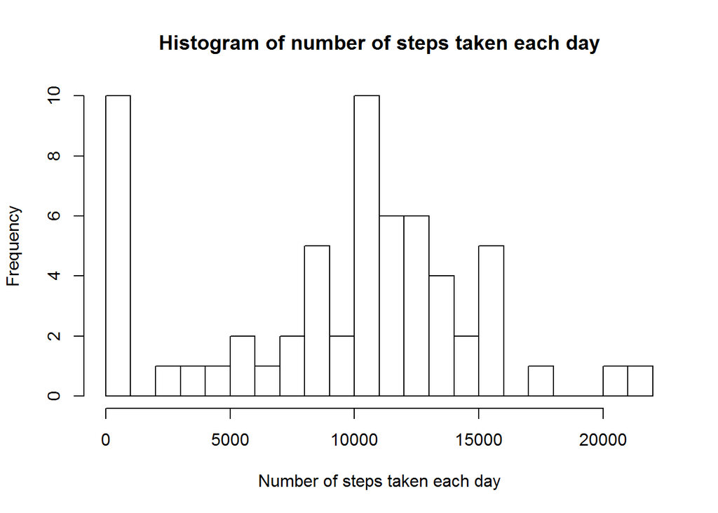

```r
hist(y$No.of.steps.taken.each.day,breaks=30,xlab="Number of steps taken each day",main="Histogram of number of steps taken each day")
```

```r
dev.copy(png,"plot1.png")
```

```r
dev.off()
```

Mean and Median of total number of steps taken each day.

```r
cat("The mean of total number of steps taken each day :",mean(y$No.of.steps.taken.each.day))
```

```
## The mean of total number of steps taken each day : 9354.23
```

```r
cat("The median of total number of steps taken each day :",median(y$No.of.steps.taken.each.day))
```

```
## The median of total number of steps taken each day : 10395
```

Average daily activity pattern

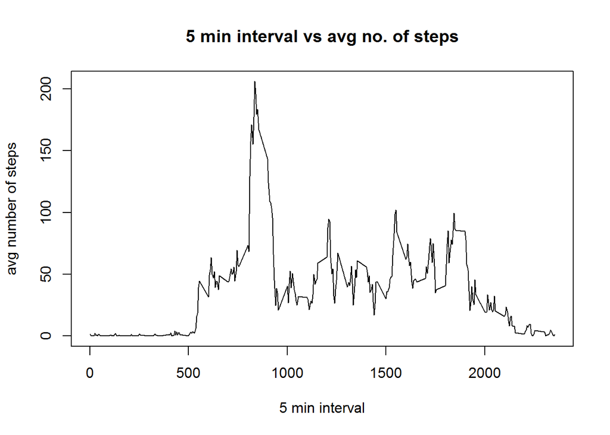

```r
tmp=group_by(df,interval)
avgsteps=summarise(tmp,average.no.of.steps=mean(steps,na.rm=TRUE))
plot(avgsteps$interval,avgsteps$average.no.of.steps,"l",main="5 min interval vs avg no. of steps",xlab="5 min interval",ylab ="avg number of steps")
```

```r
dev.copy(png,"plot2.png")
```

```r
dev.off()
```

The 5-minute interval, on average across all the days in the dataset, containing the maximum number of steps

```r
cat("5 min interval with maximum number of steps:",avgsteps[[which.max(avgsteps$average.no.of.steps),"interval"]])
```

```
## 5 min interval with maximum number of steps: 835
```

```r
olddf=df
```

Number of missing values

```r
cat("Number of missing values",sum(is.na(df)))
```

```
## Number of missing values 2304
```

Imputing missing values based on 5 min interval

```r
for(i in seq(1,nrow(df),1)){
    if(is.na(df[i,"steps"])){
        df[i,"steps"]=mean(df[df$interval==df[i,"interval"],"steps"],na.rm=TRUE)

    }

}
```

Histogram of the total number of steps taken each day

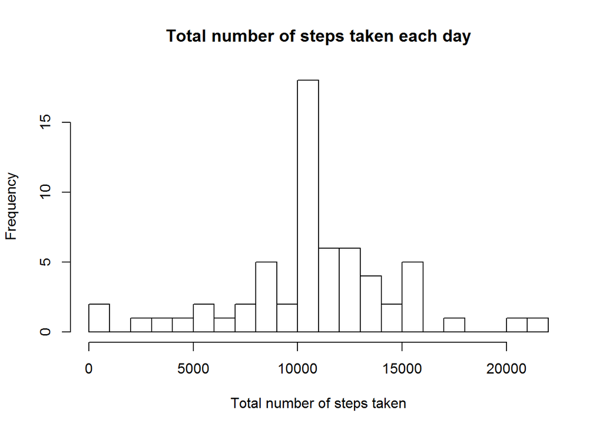

```r
grpday=group_by(df,date)
steps=summarise(grpday,total.no.of.steps.taken=sum(steps))
hist(steps$total.no.of.steps.taken,breaks=30,xlab="Total number of steps taken",main="Total number of steps taken each day")
```

```r
dev.copy(png,"plot3.png")
```

```r
dev.off()
```

Mean and Median of total number of steps taken per day

```r
cat("Mean of total number of steps taken per day:",mean(steps$total.no.of.steps.taken))
```

```
## Mean of total number of steps taken per day: 10766.19
```

```r
cat("Median of total number of steps taken per day:",median(steps$total.no.of.steps.taken))
```

```
## Median of total number of steps taken per day: 10766.19
```

Creating a new factor variable “day” in the dataset with two levels - “weekday” and “weekend” indicating whether a given date is a weekday or weekend day.

```r
for(i in seq(1,nrow(df),1)){
    if(weekdays(df[i,"date"])=="Sunday"|weekdays(df[i,"date"])=="Saturday"){
        df[i,"day"]="weekend"

    }else{
        df[i,"day"]="weekday"

    }
}
```

Making a panel plot containing a time series plot (i.e. type = “l”) of the 5-minute interval (x-axis) and the average number of steps taken, averaged across all weekday days or weekend days (y-axis).

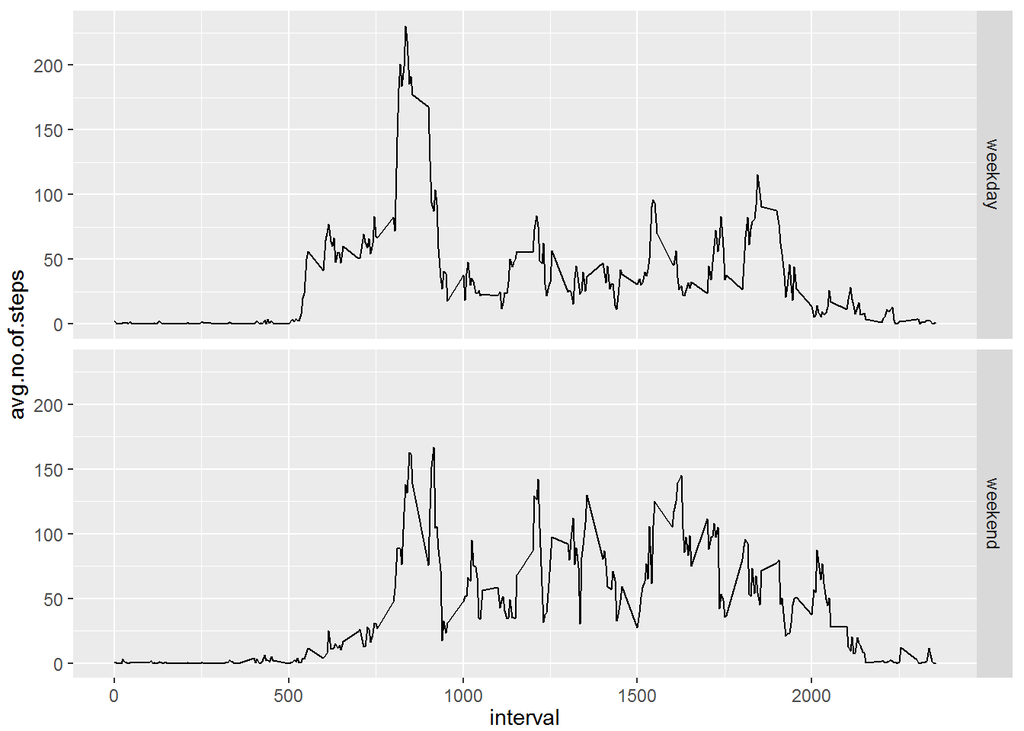

```r
df$day=as.factor(df$day)
intervalgrp=group_by(df,interval,day)
dayintsteps=summarise(intervalgrp,avg.no.of.steps=mean(steps,na.rm=TRUE))
library(ggplot2)
ggplot(dayintsteps,aes(x=interval,y=avg.no.of.steps))+ geom_line()+facet_grid(day~.)
```

```r
dev.copy(png,"plot4.png")
```

```r
dev.off()
```